# Part I - (Flights Data Exploration)

### Distribution of departure delay and arrival delay in different months

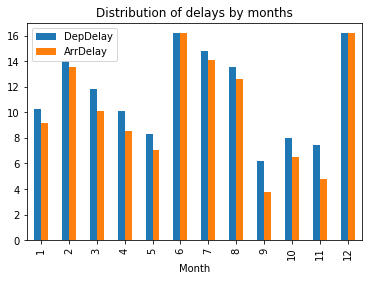

```python
# https://shawnemhe.github.io/udacity-data-analyst/p6/python_eda/python_eda.html
# I grouped the dataset by month, and got the average departure delay, and arrival delay
df.groupby('Month').agg({'DepDelay':'mean', 'ArrDelay':'mean'}).plot.bar()
chart_label('Distribution of delays by months')
plt.show()
```

June, and December, experienced the most frequent delays for both arrival and departures

### Distribution of Departure Delay And Arrival Delay on different days

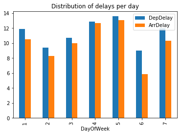

```python
df.groupby('DayOfWeek').agg({'DepDelay':'mean', 'ArrDelay':'mean'}).plot.bar()
chart_label('Distribution of delays per day')
plt.show()
```

Fridays are seen to have the highest departure and arrival delays, while on saturdays have the lowest the lowest values on saturdays might be explained by the fact that the volume of flights taking place on saturdays is usually less than other days. There are generally more departure delays than arrival delays

### What is the distribution of delayed flights across months in a year

```
Text(0.5,1,'Distribution of delays for each month')
```

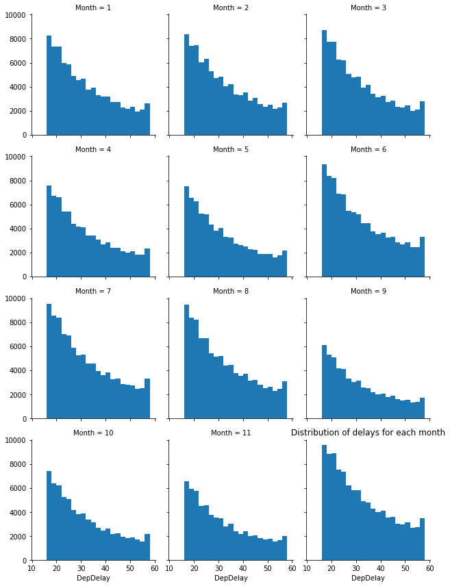

```python
#Ref: Udacity Classroom
delayed_flights = df[df['DepDelay'] > 15]
bin_edges = np.arange(12, 58+2, 2)
g = sb.FacetGrid(data = delayed_flights, col = 'Month', col_wrap=3)
g.map(plt.hist, 'DepDelay', bins = bin_edges);
chart_label('Distribution of delays for each month')
```

There is a roughly similar trend across the months, with September experiencing a smaller distribution of delays

### Correlation matrix across variables with a Delayed flight

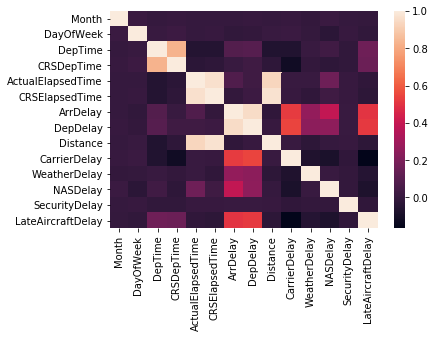

```python
corrMatrix = delayed_flights.corr()
sb.heatmap(corrMatrix)
plt.show()
```

We can see the correlation of all numerical values of the dataset

### What is the distribution of reasons for cancellations across months

```
Text(0.5,1,'Distribution of Cancellations by month')
```

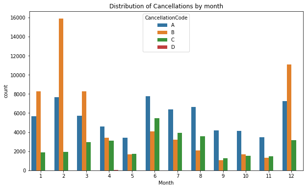

```python
plt.figure(figsize=[10,6])
sb.countplot(data=dfCancelled, x='Month',hue='CancellationCode')
chart_label('Distribution of Cancellations by month')
```

> reason for cancellation (A = carrier, B = weather, C = NAS, D = security)
> - December to March had very high cancellations of flights due to weather, with the peak occuring in February
> - There seemed to be a cancellation due to security in April, but generally, across the dataset, cancellations due to security was not common place

### Talk about some of the relationships you observed in this part of the investigation. How did the feature(s) of interest vary with other features in the dataset?

June, and December, experienced the most frequent delays for both arrival and departures

### Did you observe any interesting relationships between the other features (not the main feature(s) of interest)?

As the distance of a trip increases, the actual Elapsed Time also increases...Although there are a few outliers, where the time spent is greater than the corresponding distance

## Multivariate Exploration

> Create plots of three or more variables to investigate your data even further. Make sure that your investigations are justified, and follow from your work in the previous sections.

### Variation of the different delay reasons by months

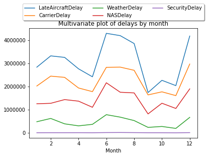

```python
# ref: https://www.kaggle.com/code/adveros/flight-delay-eda-exploratory-data-analysis/notebook
delayed_df = delayed_flights.filter(['Month','CarrierDelay','WeatherDelay','NASDelay','SecurityDelay','LateAircraftDelay'], axis=1)
delayed_df = delayed_df.groupby('Month')['LateAircraftDelay','CarrierDelay','WeatherDelay','NASDelay','SecurityDelay'].sum().plot()
delayed_df.legend(loc='upper center', bbox_to_anchor=(0.5, 1.25), ncol=3, fancybox=True, shadow=True)
chart_label('Multivariate plot of delays by month')
plt.show()
```

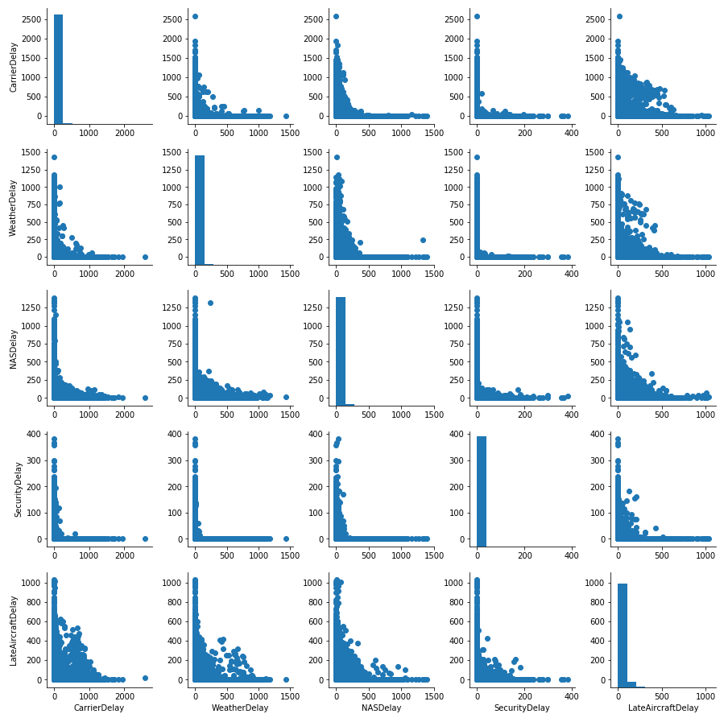

```python
delays=['CarrierDelay', 'WeatherDelay', 'NASDelay', 'SecurityDelay', 'LateAircraftDelay']
g=sb.PairGrid(data=delayed_flights, vars=delays);
g=g.map_offdiag(plt.scatter);
g.map_diag(plt.hist)
```

This shows the correlatin of the delay reasons among themselves

```python
# getting the correllaton of delays
delayed_flights[delays].corr()
```

|  | CarrierDelay | WeatherDelay | NASDelay | SecurityDelay | LateAircraftDelay |
| --- | --- | --- | --- | --- | --- |
| CarrierDelay | 1.000000 | -0.066502 | -0.081487 | -0.016126 | -0.165070 |
| WeatherDelay | -0.066502 | 1.000000 | 0.010923 | -0.007151 | -0.049439 |
| NASDelay | -0.081487 | 0.010923 | 1.000000 | -0.009014 | -0.072089 |
| SecurityDelay | -0.016126 | -0.007151 | -0.009014 | 1.000000 | -0.015355 |
| LateAircraftDelay | -0.165070 | -0.049439 | -0.072089 | -0.015355 | 1.000000 |

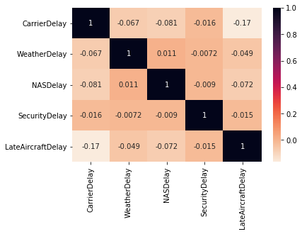

```python
sb.heatmap(delayed_flights[delays].corr(), cmap='rocket_r', annot=True);
```

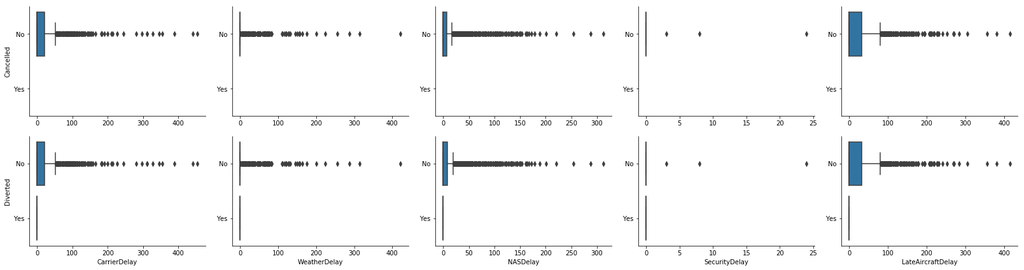

```python
delayed_samp = delayed_flights.sample(n=2000, replace = False)
def boxgrid(x, y, **kwargs):
    """ Quick hack for creating box plots with seaborn's PairGrid. """
    default_color = sb.color_palette()[0]
    sb.boxplot(x=x, y=y, color=default_color)

plt.figure(figsize = [10, 10])
g = sb.PairGrid(data = delayed_samp, y_vars = ['Cancelled', 'Diverted'], x_vars = ['CarrierDelay', 'WeatherDelay', 'NASDelay', 'SecurityDelay', 'LateAircraftDelay'],
                size = 3, aspect = 1.5)
g.map(boxgrid)
plt.show();
```

None of the delayed flights in the data sET resulted in a cancellation, but a few Delayed Flights experienced diversions

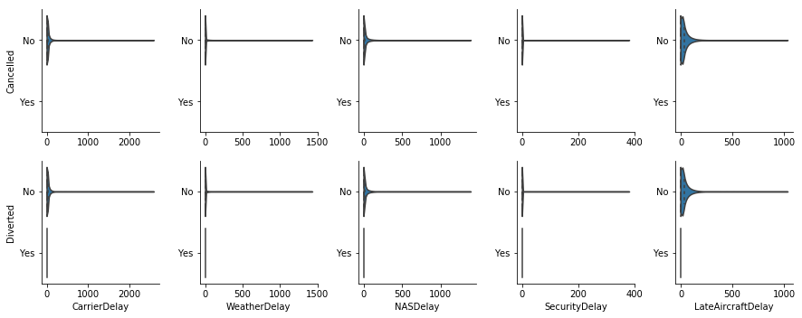

```python
g = sb.PairGrid(data = delayed_flights, x_vars = ['CarrierDelay', 'WeatherDelay', 'NASDelay', 'SecurityDelay', 'LateAircraftDelay'],
                y_vars = ['Cancelled', 'Diverted'])
g.map(sb.violinplot, inner = 'quartile')
```

Violin plot showing the relationship between the types of delays, and Cancellation/ Diversions. N/b: This plot does not accurately convey its message.

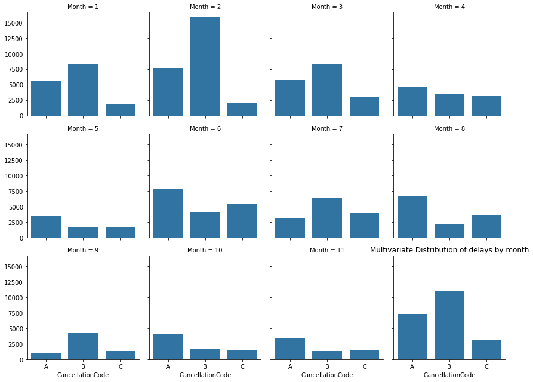

```python
plt.figure(figsize = [12,10])
g=sb.FacetGrid(data = dfCancelled, col = 'Month', col_wrap=4, size=3)
g.map(sb.countplot, 'CancellationCode')
chart_label('Multivariate Distribution of delays by month')
plt.show()
```

### Talk about some of the relationships you observed in this part of the investigation. Were there features that strengthened each other in terms of looking at your feature(s) of interest?

> The second most frequent cause of delay, was due to Carrier delays, corroborating my position that some Carriers are notorious for delays In February and December, the Cancellation code was highest for weather plotting a multivariate distribution of the cancellation codes on a mnthly basis further strengthened the visibility of this relationship

### Were there any interesting or surprising interactions between features?

- None of the delayed flights in the data set got cancelled, but some delays could be as a result of diversions- certain Delayed Flights experienced diversions.
- The peak monthly Delays were recorded in June